# SQL 入門

> 快速啟動

郭耀仁

## 摘要

- 環境設定
- 釋義的部分
- 從 `SELECT` 與 `FROM` 開始
- 隨堂練習
- 隨堂練習參考解答

## 環境設定

## 為了讓學生能夠直接進入學習 SQL 的環節，我們設置了一個[雲端環境](https://mybinder.org/v2/gh/yaojenkuo/introduction-to-sql/master)

這個[雲端環境](https://mybinder.org/v2/gh/yaojenkuo/introduction-to-sql/master)是透過下面幾個應用程式所搭建而成：

- [Binder](https://mybinder.org/)
- [GitHub](https://github.com/)
- [Project Jupyter](https://jupyter.org/)
- [SQLite](https://www.sqlite.org/index.html)
- [Python](https://www.python.org/)
- [Pandas](https://pandas.pydata.org/)

## [雲端環境](https://mybinder.org/v2/gh/yaojenkuo/introduction-to-sql/master)該如何使用？

- 在開頭的 `"""` 與結尾的 `"""` 之間撰寫 SQL 語法
- 透過 `pandas` 與 `sqlite3` 傳送給 SQLite 資料庫
- 點選 `>| Run` 執行儲存格

## 故障排除

- Kernel > Restart & Run All
- 重新啟動

## SQL 語法會用一個 Python 長字串包裝起來

長字串由開頭的 `"""` 與結尾的 `"""`組合起來。

```
sql_query = """
SELECT column_name FROM table_name; -- 將 SQL 語法寫在長字串裡頭
"""
```

## SQL 語法會透過 `pandas` 與 `sqlite3` 傳送給 SQLite 資料庫

```
# 連結資料庫
import sqlite3
import pandas as pd

sql_query = """
SELECT column_name FROM table_name; -- 將 SQL 語法寫在長字串裡頭
"""
conn = sqlite3.connect('database_name.db')
pd.read_sql(sql_query, conn)
```

## 輸出會得到一個 `DataFrame`，舉例來說

```python
# 連結資料庫
import sqlite3
import pandas as pd

conn_nba = sqlite3.connect('nba.db')
```

```python
sql_query = """
SELECT *
  FROM players
 WHERE firstName = 'LeBron';
"""
pd.read_sql(sql_query, conn_nba)
```

|  | firstName | lastName | temporaryDisplayName | personId | teamId | jersey | isActive | pos | heightFeet | heightInches | heightMeters | weightPounds | weightKilograms | dateOfBirthUTC | nbaDebutYear | yearsPro | collegeName | lastAffiliation | country | isallStar |
| --- | --- | --- | --- | --- | --- | --- | --- | --- | --- | --- | --- | --- | --- | --- | --- | --- | --- | --- | --- | --- |
| 0 | LeBron | James | James, LeBron | 2544 | 1610612747 | 23 | True | F | 6 | 9 | 2.06 | 250 | 113.4 | 1984-12-30 | 2003 | 16 | None | St. Vincent-St. Mary HS (OH)/USA | USA | None |

## 已知的限制

- 閒置 10 分鐘環境就會關閉
- 重新啟動環境後所有的變更都會還原

## 釋義的部分

## 什麼是 SQL

> SQL(發音為 ess-que-ell 或 sequel)，是一個為資料庫所設計的語法，於 1970 年代由 IBM 開發問世，後來成為業界通用的資料庫標準語法。使用 SQL 可以針對資料庫進行 CRUD 的操作，其中 C 指的是創建（Create）、R 指的是查詢（Read）、U 指的是更新（Update）、D 指的是刪除（Delete）。

## 什麼是資料庫

> 資料庫是具有屬性（Attributes）的觀測值（Records）集合，由資料與資料描述（Metadata）組合而成。

## 例如具有多個屬性的隊伍觀測值

```python
sql_query = """
SELECT *
  FROM teams
 LIMIT 1;
"""
pd.read_sql(sql_query, conn_nba)
```

|  | isNBAFranchise | isAllStar | city | altCityName | fullName | tricode | teamId | nickname | urlName | teamShortName | confName | divName |
| --- | --- | --- | --- | --- | --- | --- | --- | --- | --- | --- | --- | --- |
| 0 | True | False | Atlanta | Atlanta | Atlanta Hawks | ATL | 1610612737 | Hawks | hawks | Atlanta | East | Southeast |

## 例如具有多個屬性的球員觀測值

```python
sql_query = """
SELECT *
  FROM players
 LIMIT 1;
"""
pd.read_sql(sql_query, conn_nba)
```

|  | firstName | lastName | temporaryDisplayName | personId | teamId | jersey | isActive | pos | heightFeet | heightInches | heightMeters | weightPounds | weightKilograms | dateOfBirthUTC | nbaDebutYear | yearsPro | collegeName | lastAffiliation | country | isallStar |
| --- | --- | --- | --- | --- | --- | --- | --- | --- | --- | --- | --- | --- | --- | --- | --- | --- | --- | --- | --- | --- |
| 0 | Vince | Carter | Carter, Vince | 1713 | 1610612737 | 15 | True | G-F | 6 | 6 | 1.98 | 220 | 99.8 | 1977-01-26 | 1998 | 21 | North Carolina | North Carolina/USA | USA | None |

## 所以，Metadata 到底是什麼

[figure not shown]

Source: https://giphy.com/

## Metadata 是描述資料庫中結構的內容，也以資料的形式存在於資料庫中

## 描述資料庫中有哪些表格

從 `sqlite_master` 表格中查詢。

```python
sql_query = """
SELECT type,
       name
  FROM sqlite_master;
"""
pd.read_sql(sql_query, conn_nba)
```

|  | type | name |
| --- | --- | --- |
| 0 | table | teams |
| 1 | table | rosters |
| 2 | table | players |
| 3 | table | careerSummaries |

## 描述資料庫中表格有哪些欄位

`PRAGMA TABLE_INFO(tbl_name);`

```python
sql_query = """
PRAGMA TABLE_INFO(teams);
"""
```

```python
pd.read_sql(sql_query, conn_nba)
```

|  | cid | name | type | notnull | dflt_value | pk |
| --- | --- | --- | --- | --- | --- | --- |
| 0 | 0 | isNBAFranchise | TEXT | 0 | None | 0 |
| 1 | 1 | isAllStar | TEXT | 0 | None | 0 |
| 2 | 2 | city | TEXT | 0 | None | 0 |
| 3 | 3 | altCityName | TEXT | 0 | None | 0 |
| 4 | 4 | fullName | TEXT | 0 | None | 0 |
| 5 | 5 | tricode | TEXT | 0 | None | 0 |
| 6 | 6 | teamId | INTEGER | 0 | None | 1 |
| 7 | 7 | nickname | TEXT | 0 | None | 0 |
| 8 | 8 | urlName | TEXT | 0 | None | 0 |
| 9 | 9 | teamShortName | TEXT | 0 | None | 0 |
| 10 | 10 | confName | TEXT | 0 | None | 0 |
| 11 | 11 | divName | TEXT | 0 | None | 0 |

## 為什麼 SQL

- SQL 是資料科學團隊、軟體開發團隊最為倚賴的語言之一
- SQL 對程式語言有良好的介接

## 舉 2019 年的 [Kaggle ML & DS Survey](https://www.kaggle.com/c/kaggle-survey-2019) 為例

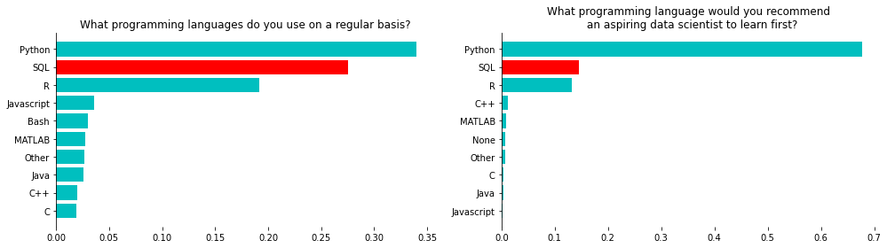

```python
plot_ans_18_19(ans_18, ans_19)
```

## 為什麼資料庫

- 資料庫是網頁應用程式、互動地圖或內容管理系統不可或缺的後端
- 使用資料庫可以幫助我們將資料的 CRUD 規模化與自動化

## 資料的 CRUD

- C(reate) 創建
- R(ead) 讀取
- U(pdate) 更新
- D(elete) 刪除

## 從 `SELECT` 與 `FROM` 開始

## 兩個維度的資料

- 水平：觀測值（Observations）、列（Rows）
- 垂直：變數（Variables）、欄（Columns）

## 使用 `SELECT *` 查詢表格 `teams` 中的所有觀測值與變數

- 使用 `*` 代表「所有」的變數
- 使用 `FROM` 指定表格
- 使用 `;` 表示查詢的終結

```python
sql_query = """
SELECT *
  FROM teams;
"""
pd.read_sql(sql_query, conn_nba)
```

|  | isNBAFranchise | isAllStar | city | altCityName | fullName | tricode | teamId | nickname | urlName | teamShortName | confName | divName |
| --- | --- | --- | --- | --- | --- | --- | --- | --- | --- | --- | --- | --- |
| 0 | True | False | Atlanta | Atlanta | Atlanta Hawks | ATL | 1610612737 | Hawks | hawks | Atlanta | East | Southeast |
| 1 | True | False | Boston | Boston | Boston Celtics | BOS | 1610612738 | Celtics | celtics | Boston | East | Atlantic |
| 2 | True | False | Cleveland | Cleveland | Cleveland Cavaliers | CLE | 1610612739 | Cavaliers | cavaliers | Cleveland | East | Central |
| 3 | True | False | New Orleans | New Orleans | New Orleans Pelicans | NOP | 1610612740 | Pelicans | pelicans | New Orleans | West | Southwest |
| 4 | True | False | Chicago | Chicago | Chicago Bulls | CHI | 1610612741 | Bulls | bulls | Chicago | East | Central |
| 5 | True | False | Dallas | Dallas | Dallas Mavericks | DAL | 1610612742 | Mavericks | mavericks | Dallas | West | Southwest |
| 6 | True | False | Denver | Denver | Denver Nuggets | DEN | 1610612743 | Nuggets | nuggets | Denver | West | Northwest |
| 7 | True | False | Golden State | Golden State | Golden State Warriors | GSW | 1610612744 | Warriors | warriors | Golden State | West | Pacific |
| 8 | True | False | Houston | Houston | Houston Rockets | HOU | 1610612745 | Rockets | rockets | Houston | West | Southwest |
| 9 | True | False | LA | LA Clippers | LA Clippers | LAC | 1610612746 | Clippers | clippers | LA Clippers | West | Pacific |
| 10 | True | False | Los Angeles | Los Angeles Lakers | Los Angeles Lakers | LAL | 1610612747 | Lakers | lakers | L.A. Lakers | West | Pacific |
| 11 | True | False | Miami | Miami | Miami Heat | MIA | 1610612748 | Heat | heat | Miami | East | Southeast |
| 12 | True | False | Milwaukee | Milwaukee | Milwaukee Bucks | MIL | 1610612749 | Bucks | bucks | Milwaukee | East | Central |
| 13 | True | False | Minnesota | Minnesota | Minnesota Timberwolves | MIN | 1610612750 | Timberwolves | timberwolves | Minnesota | West | Northwest |
| 14 | True | False | Brooklyn | Brooklyn | Brooklyn Nets | BKN | 1610612751 | Nets | nets | Brooklyn | East | Atlantic |
| 15 | True | False | New York | New York | New York Knicks | NYK | 1610612752 | Knicks | knicks | New York | East | Atlantic |
| 16 | True | False | Orlando | Orlando | Orlando Magic | ORL | 1610612753 | Magic | magic | Orlando | East | Southeast |
| 17 | True | False | Indiana | Indiana | Indiana Pacers | IND | 1610612754 | Pacers | pacers | Indiana | East | Central |
| 18 | True | False | Philadelphia | Philadelphia | Philadelphia 76ers | PHI | 1610612755 | 76ers | sixers | Philadelphia | East | Atlantic |
| 19 | True | False | Phoenix | Phoenix | Phoenix Suns | PHX | 1610612756 | Suns | suns | Phoenix | West | Pacific |
| 20 | True | False | Portland | Portland | Portland Trail Blazers | POR | 1610612757 | Trail Blazers | blazers | Portland | West | Northwest |
| 21 | True | False | Sacramento | Sacramento | Sacramento Kings | SAC | 1610612758 | Kings | kings | Sacramento | West | Pacific |
| 22 | True | False | San Antonio | San Antonio | San Antonio Spurs | SAS | 1610612759 | Spurs | spurs | San Antonio | West | Southwest |
| 23 | True | False | Oklahoma City | Oklahoma City | Oklahoma City Thunder | OKC | 1610612760 | Thunder | thunder | Oklahoma City | West | Northwest |
| 24 | True | False | Toronto | Toronto | Toronto Raptors | TOR | 1610612761 | Raptors | raptors | Toronto | East | Atlantic |
| 25 | True | False | Utah | Utah | Utah Jazz | UTA | 1610612762 | Jazz | jazz | Utah | West | Northwest |
| 26 | True | False | Memphis | Memphis | Memphis Grizzlies | MEM | 1610612763 | Grizzlies | grizzlies | Memphis | West | Southwest |
| 27 | True | False | Washington | Washington | Washington Wizards | WAS | 1610612764 | Wizards | wizards | Washington | East | Southeast |
| 28 | True | False | Detroit | Detroit | Detroit Pistons | DET | 1610612765 | Pistons | pistons | Detroit | East | Central |
| 29 | True | False | Charlotte | Charlotte | Charlotte Hornets | CHA | 1610612766 | Hornets | hornets | Charlotte | East | Southeast |

## 在 `SELECT` 後指定變數，並以逗號間隔

```python
sql_query = """
SELECT firstName,
       lastName,
       dateOfBirthUTC
  FROM players;
"""
pd.read_sql(sql_query, conn_nba)
```

|  | firstName | lastName | dateOfBirthUTC |
| --- | --- | --- | --- |
| 0 | Vince | Carter | 1977-01-26 |
| 1 | Tyson | Chandler | 1982-10-02 |
| 2 | LeBron | James | 1984-12-30 |
| 3 | Carmelo | Anthony | 1984-05-29 |
| 4 | Kyle | Korver | 1981-03-17 |
| ... | ... | ... | ... |
| 499 | Matt | Thomas | 1994-08-04 |
| 500 | Tariq | Owens | 1995-06-30 |
| 501 | Javonte | Green | 1993-07-23 |
| 502 | Juwan | Morgan | 1997-04-17 |
| 503 | Matt | Mooney | 1997-02-07 |

504 rows × 3 columns

## 使用 `DISTINCT` 暸解類別變數的獨一值

```python
sql_query = """
SELECT DISTINCT confName,
       divName
  FROM teams;
"""
pd.read_sql(sql_query, conn_nba)
```

|  | confName | divName |
| --- | --- | --- |
| 0 | East | Southeast |
| 1 | East | Atlantic |
| 2 | East | Central |
| 3 | West | Southwest |
| 4 | West | Northwest |
| 5 | West | Pacific |

## 使用 `LIMIT` 侷限查詢結果的觀測值數

```python
sql_query = """
SELECT city
  FROM teams
 LIMIT 5;
"""
pd.read_sql(sql_query, conn_nba)
```

|  | city |
| --- | --- |
| 0 | Atlanta |
| 1 | Boston |
| 2 | Cleveland |
| 3 | New Orleans |
| 4 | Chicago |

## 使用 `AS` 為查詢結果建立別名

```python
sql_query = """
SELECT fullName AS team_name
  FROM teams
 LIMIT 5;
"""
pd.read_sql(sql_query, conn_nba)
```

|  | team_name |
| --- | --- |
| 0 | Atlanta Hawks |
| 1 | Boston Celtics |
| 2 | Cleveland Cavaliers |
| 3 | New Orleans Pelicans |
| 4 | Chicago Bulls |

## 這是目前涵蓋的查詢保留字

使用 SQL 語法時，保留字順序必須要遵守。

```
SELECT DISTINCT column_name AS alias_name
  FROM table_name
 LIMIT n_obs;
```

## 隨堂練習

[快速啟動：隨堂練習](https://mybinder.org/v2/gh/yaojenkuo/introduction-to-sql/master?filepath=01-exercises.ipynb)

## 隨堂練習：由 `sqlite_master` 表格中選擇 `type` 與 `name` 這兩個欄位暸解 `twelection.db` 中有哪些表格

```python
expected_output
```

|  | type | name |
| --- | --- | --- |
| 0 | table | presidential2016 |
| 1 | table | presidential2020 |

## 隨堂練習：使用 `PRAGMA` 指令與 `TABLE_INFO()` 函式暸解 `presidential2020` 中有哪些欄位

```python
expected_output
```

|  | cid | name | type | notnull | dflt_value | pk |
| --- | --- | --- | --- | --- | --- | --- |
| 0 | 0 | county | TEXT | 0 | None | 0 |
| 1 | 1 | town | TEXT | 0 | None | 0 |
| 2 | 2 | village | TEXT | 0 | None | 0 |
| 3 | 3 | office | INTEGER | 0 | None | 0 |
| 4 | 4 | number | INTEGER | 0 | None | 0 |
| 5 | 5 | candidates | TEXT | 0 | None | 0 |
| 6 | 6 | votes | INTEGER | 0 | None | 0 |

## 隨堂練習：使用 `SELECT *` 將 `presidential2020` 中有哪些資料都查詢出來

```python
expected_output
```

|  | county | town | village | office | number | candidates | votes |
| --- | --- | --- | --- | --- | --- | --- | --- |
| 0 | 南投縣 | 中寮鄉 | 中寮村 | 366 | 1 | 宋楚瑜/余湘 | 18 |
| 1 | 南投縣 | 中寮鄉 | 中寮村 | 366 | 2 | 韓國瑜/張善政 | 217 |
| 2 | 南投縣 | 中寮鄉 | 中寮村 | 366 | 3 | 蔡英文/賴清德 | 208 |
| 3 | 南投縣 | 中寮鄉 | 內城村 | 373 | 1 | 宋楚瑜/余湘 | 17 |
| 4 | 南投縣 | 中寮鄉 | 內城村 | 373 | 2 | 韓國瑜/張善政 | 141 |
| ... | ... | ... | ... | ... | ... | ... | ... |
| 51673 | 高雄市 | 鼓山區 | 龍水里 | 1268 | 2 | 韓國瑜/張善政 | 477 |
| 51674 | 高雄市 | 鼓山區 | 龍水里 | 1268 | 3 | 蔡英文/賴清德 | 647 |
| 51675 | 高雄市 | 鼓山區 | 龍水里 | 1269 | 1 | 宋楚瑜/余湘 | 39 |
| 51676 | 高雄市 | 鼓山區 | 龍水里 | 1269 | 2 | 韓國瑜/張善政 | 520 |
| 51677 | 高雄市 | 鼓山區 | 龍水里 | 1269 | 3 | 蔡英文/賴清德 | 673 |

51678 rows × 7 columns

## 隨堂練習：使用 `SELECT` 將 `presidential2020` 表格中的 `county`、`town` 與 `village` 三個欄位選擇出來

```python
expected_output
```

|  | county | town | village |
| --- | --- | --- | --- |
| 0 | 南投縣 | 中寮鄉 | 中寮村 |
| 1 | 南投縣 | 中寮鄉 | 中寮村 |
| 2 | 南投縣 | 中寮鄉 | 中寮村 |
| 3 | 南投縣 | 中寮鄉 | 內城村 |
| 4 | 南投縣 | 中寮鄉 | 內城村 |
| ... | ... | ... | ... |
| 51673 | 高雄市 | 鼓山區 | 龍水里 |
| 51674 | 高雄市 | 鼓山區 | 龍水里 |
| 51675 | 高雄市 | 鼓山區 | 龍水里 |
| 51676 | 高雄市 | 鼓山區 | 龍水里 |
| 51677 | 高雄市 | 鼓山區 | 龍水里 |

51678 rows × 3 columns

## 隨堂練習：使用 `DISTINCT` 檢視 `presidential2020` 表格中的 `candidates` 有幾組候選人參選

```python
expected_output
```

|  | candidates |
| --- | --- |
| 0 | 宋楚瑜/余湘 |
| 1 | 韓國瑜/張善政 |
| 2 | 蔡英文/賴清德 |

## 隨堂練習：使用 `DISTINCT` 檢視 `presidential2016` 表格中的 `candidates` 有幾組候選人參選

```python
expected_output
```

|  | candidates |
| --- | --- |
| 0 | 朱立倫/王如玄 |
| 1 | 蔡英文/陳建仁 |
| 2 | 宋楚瑜/徐欣瑩 |

## 隨堂練習：使用 `LIMIT` 檢視 `presidential2020` 表格中的前 10 個觀測值

```python
expected_output
```

|  | county | town | village | office | number | candidates | votes |
| --- | --- | --- | --- | --- | --- | --- | --- |
| 0 | 南投縣 | 中寮鄉 | 中寮村 | 366 | 1 | 宋楚瑜/余湘 | 18 |
| 1 | 南投縣 | 中寮鄉 | 中寮村 | 366 | 2 | 韓國瑜/張善政 | 217 |
| 2 | 南投縣 | 中寮鄉 | 中寮村 | 366 | 3 | 蔡英文/賴清德 | 208 |
| 3 | 南投縣 | 中寮鄉 | 內城村 | 373 | 1 | 宋楚瑜/余湘 | 17 |
| 4 | 南投縣 | 中寮鄉 | 內城村 | 373 | 2 | 韓國瑜/張善政 | 141 |
| 5 | 南投縣 | 中寮鄉 | 內城村 | 373 | 3 | 蔡英文/賴清德 | 139 |
| 6 | 南投縣 | 中寮鄉 | 八仙村 | 358 | 1 | 宋楚瑜/余湘 | 13 |
| 7 | 南投縣 | 中寮鄉 | 八仙村 | 358 | 2 | 韓國瑜/張善政 | 111 |
| 8 | 南投縣 | 中寮鄉 | 八仙村 | 358 | 3 | 蔡英文/賴清德 | 119 |
| 9 | 南投縣 | 中寮鄉 | 八仙村 | 359 | 1 | 宋楚瑜/余湘 | 8 |

## 隨堂練習：使用 `DISTINCT` 檢視 `presidential2020` 表格中的 `county` 有幾個縣市，並以 `AS` 將 `county` 命名為 `distinct_counties`

```python
expected_output
```

|  | distinct_counties |
| --- | --- |
| 0 | 南投縣 |
| 1 | 嘉義市 |
| 2 | 嘉義縣 |
| 3 | 基隆市 |
| 4 | 宜蘭縣 |
| 5 | 屏東縣 |
| 6 | 彰化縣 |
| 7 | 新北市 |
| 8 | 新竹市 |
| 9 | 新竹縣 |
| 10 | 桃園市 |
| 11 | 澎湖縣 |
| 12 | 臺中市 |
| 13 | 臺北市 |
| 14 | 臺南市 |
| 15 | 臺東縣 |
| 16 | 花蓮縣 |
| 17 | 苗栗縣 |
| 18 | 連江縣 |
| 19 | 金門縣 |
| 20 | 雲林縣 |
| 21 | 高雄市 |

## 隨堂練習參考解答

[快速啟動：隨堂練習參考解答](https://mybinder.org/v2/gh/yaojenkuo/introduction-to-sql/master?filepath=01-suggested-answers.ipynb)